# 臺灣の抹茶冰淇淋山不好爬-宜蘭縣山域意外頻傳

林詠琪 109464034 傳播所碩一

2018年7月，一名熱愛臺灣的日本攝影師[小林賢伍](https://www.instagram.com/iamnotkengo/)，偶然地來到宜蘭縣五峰旗山，被眼前批覆著綠色草浪的疊嶺層巒，深深吸引住，他拍下照片上傳至[社群媒體](https://www.facebook.com/kengokobayashijp/posts/885917868267205)，還取了俏皮的名字「臺灣の抹茶冰淇淋山。」照片一夕爆紅，吸引各方人馬一睹抹茶山的風貌，在連假期間，甚至需要[人流管制](https://www.cna.com.tw/news/ahel/202005020034.aspx)，但隨之而來的，是山難事故也大幅增加。

根據宜蘭縣消防局統計，2020年宜蘭縣山難救援共有26件，其中20件就發生在抹茶山，比前年2019年佔比更高，而今年第一季（1-3月）9件出勤更是全部都發生在這裡。

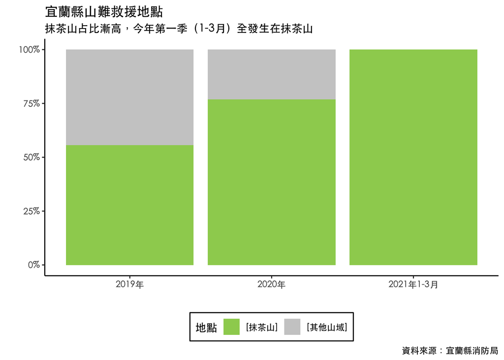

抹茶山海拔將近1000公尺，路程來回約11公里，花費時間約5到7小時，許多遊客以為只是簡單的登山步道，但它以前可是宜蘭縣消防局「初級登山救援訓練場所」，毫無事前準備便前來挑戰，導致走不動就呼叫消防的[亂象](https://www.cna.com.tw/news/asoc/202010040112.aspx)頻傳，讓救難人員疲於奔命。今年第一季（1-3月），光是山難救助出勤，救難人員就出動309人次，超過去年一整年的一半。

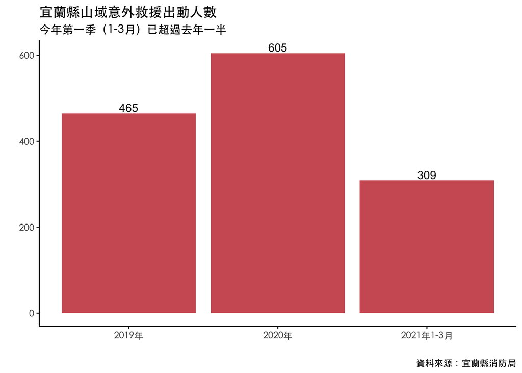

路途遙遠，費時長，加上山上氣候多變化，海拔陡升等因素，容易導致呼吸急促及暈眩情況，根據宜蘭縣消防局統計，山域事故原因以體力不支、迷路為大宗。根據[報導](https://www.cna.com.tw/news/asoc/202103190158.aspx)，去年五月，一名女子因體力不支，雖意識清楚但無法行走，由消防人員搬運下山。而今年更是傳出有民眾疑似中暑，經搶救後不幸身亡[消息](https://www.cna.com.tw/news/asoc/202103190158.aspx)，除此之外，今年三月一名阮姓婦人獨自攀爬，疑似不諳路況，留下一段詢問兒子是否迷路的[影片](https://news.ltn.com.tw/news/life/breakingnews/3478591)，就此失聯，宜蘭縣消防局集結各界派出大量人力搜救，至今仍無下落。

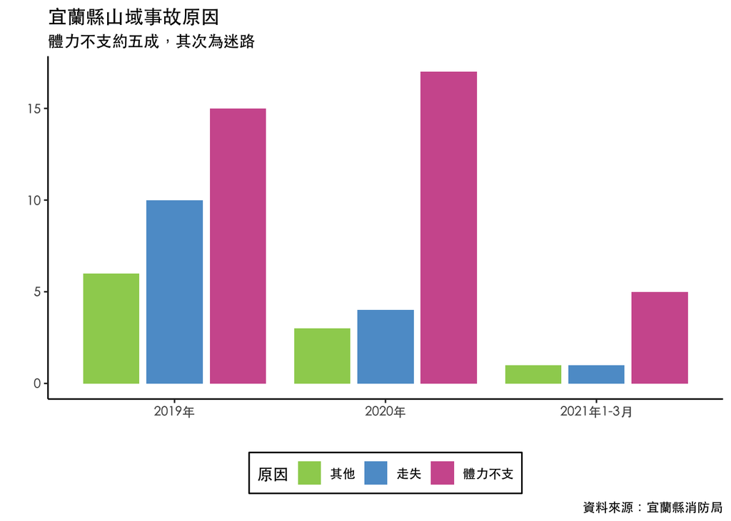

打開instagram標註抹茶山的貼文，已經有2萬多則，可見抹茶山的魅力依舊不可擋，除了社群媒體力量，也受到「COVID-19」疫情影響，臺灣民眾無法出國旅遊，國內旅遊回溫之下，登山成為熱門活動，對此，宜蘭縣消防局呼籲登山客，出發前可以下載119app，當消防局接獲電話的同時，可以獲得手機所在的位置座標，除此之外，也可至宜蘭縣[八個地點](https://yidp.e-land.gov.tw/News_Content.aspx?n=630338A7EADB7103&sms=B8B4D31F9FF4E9EC&s=395AA59BC1EF4E76)，免費借用gps導航，讓行程更加安全順利。